# Homicide Report

#### Weapon used vs Gender.

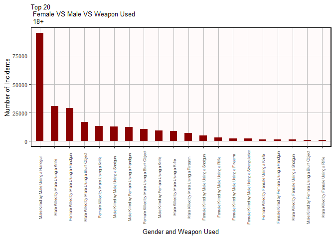

```r
by.ndf.by.weapon.used$sex.weapon.used <- fct_inorder(by.ndf.by.weapon.used$sex.weapon.used )

plot.gender.weapon.used.T20 <- ggplot(by.ndf.by.weapon.used[1:20,],aes(x = sex.weapon.used,y=freq.by.weapon.used))+
  geom_bar(stat="identity",fill="darkred",width=0.5)+
  homi.theme+
  ggtitle("Top 20 \n Female VS Male VS Weapon Used \n 18+")+
  labs(x="Gender and Weapon Used",
       y="Number of Incidents")+
 theme(axis.text.x=element_text(size= 6, angle=90,hjust = 0.5),
        axis.title.y=element_text(size=10),
        axis.title.x=element_text(size=10))+
  theme(plot.title = element_text(size = 10))

plot.gender.weapon.used.T20
```

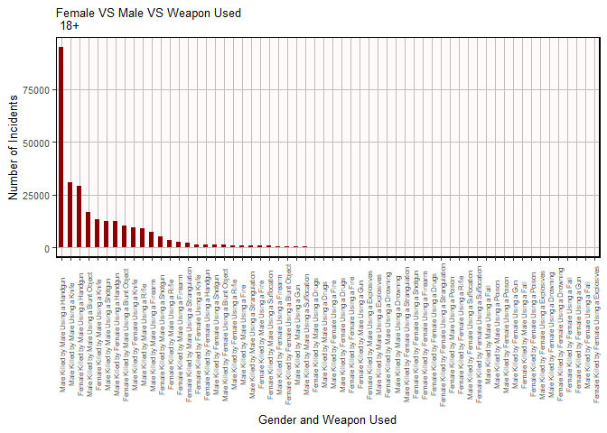

```r
by.ndf.by.weapon.used$sex.weapon.used <- fct_inorder(by.ndf.by.weapon.used$sex.weapon.used )

plot.gender.weapon.used <- ggplot(by.ndf.by.weapon.used,
                                  aes(x = sex.weapon.used,y=freq.by.weapon.used))+
  geom_bar(stat="identity",fill="darkred",width=0.5)+
  homi.theme+
  ggtitle("Female VS Male VS Weapon Used \n 18+")+
  labs(x="Gender and Weapon Used",
       y="Number of Incidents")+
  theme(axis.text.x=element_text(size= 6, angle=90,hjust = 0.5),
        axis.title.y=element_text(size=10),
        axis.title.x=element_text(size=10))+
  theme(plot.title = element_text(size = 10))

plot.gender.weapon.used
```

**Handgun** is the most used weapon by Male against Male and Female, then the **knife** and **Blunt object** as following:

1- Male Killed by Male Using a Handgun,

2- Male Killed by Male Using a Knife,

3- Female Killed by Male Using a Handgun,

4- Male Killed by Male Using a Blunt Object,

5- Female Killed by Male Using a Knife,

8- Female Killed by Male Using a Blunt Object,

9- Male Killed by Female Using a Knife and

10- Male Killed by Male Using a Rifle.

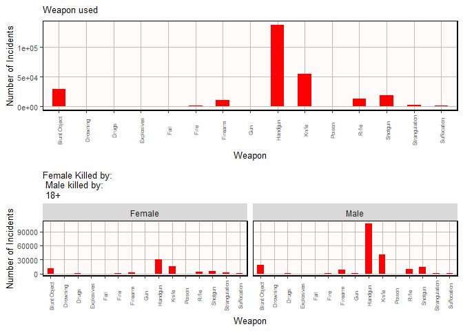

```r
Plot.weapon.used <- ggplot(by.weapon,aes(x = weapon,y=freq.by.weapon))+
geom_bar(stat = "identity",fill="red",width = 0.5)+
  homi.theme+
  ggtitle("Weapon used")+
  labs(x="Weapon",
       y="Number of Incidents")+
  theme(axis.text.x=element_text(size= 6, angle=90,hjust = 0.5),
        axis.title.y=element_text(size=10),
        axis.title.x=element_text(size=10))+
  theme(plot.title = element_text(size = 10))


plot.Weapon.vs.gender <- ggplot(by.weapon.sex,aes(x = weapon,y=freq.by.weapon))+
geom_bar(stat = "identity",fill="red",width=0.5)+
  facet_wrap(~ victim.sex)+
  homi.theme+
  ggtitle("Female Killed by: \n Male killed by: \n 18+")+
  labs(x="Weapon",
       y="Number of Incidents")+
  theme(axis.text.x=element_text(size= 6, angle=90,hjust = 0.5),
        axis.title.y=element_text(size=10),
        axis.title.x=element_text(size=10))+
  theme(plot.title = element_text(size = 10))

grid.arrange(Plot.weapon.used,
             plot.Weapon.vs.gender,
             ncol=1)
```

Numbers do not lie!

We still using the dataframe where the crime solved is “Yes”

#### Who Killed Who? ( Familicide )

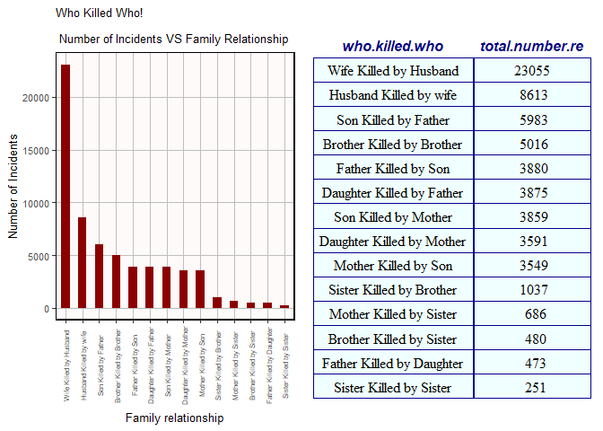

```r
by.family$who.killed.who<- fct_inorder(by.family$who.killed.who)

  plot.by.family <- ggplot(by.family,aes(x=who.killed.who, y=total.number.re ))+
    geom_bar(stat="identity", fill="darkred",width = 0.5)+
    homi.theme+
    ggtitle("Who Killed Who! \n \n Number of Incidents VS Family Relationship")+
    labs(x="Family relationship",
         y="Number of Incidents")+
    theme(axis.text.x=element_text(size= 6, angle=90,hjust = 0.5),
        axis.title.y=element_text(size=10),
        axis.title.x=element_text(size=10))+
  theme(plot.title = element_text(size = 10))


 table.by.family <- tableGrob(by.family, rows=NULL,theme = tt.homi.f)

 grid.arrange(plot.by.family,
              table.by.family,ncol=2)
```

It is painful numbers, but good to know … no need to explain what is already there… These two plots need a rich imagination and strong brainstorming.

#### Friends VS Sex

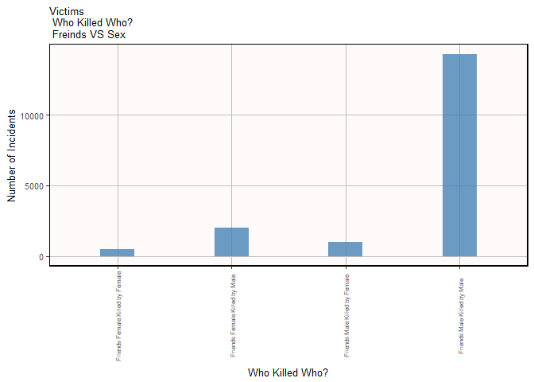

```r
ggplot(friend.crime, aes(x= who.killed.who.Friend.sex))+
  geom_bar(alpha=0.8,fill="steelblue", width=0.3)+
  homi.theme+
  ggtitle("Victims \n Who Killed Who? \n Freinds VS Sex")+
  labs(x="Who Killed Who?",
       y="Number of Incidents")+
  theme(axis.text.x=element_text(size= 6, angle=90,hjust = 0.5),
        axis.title.y=element_text(size=10),
        axis.title.x=element_text(size=10))+
  theme(plot.title = element_text(size = 10))
```

*Again men …NO COMMENTS !*

#### Employee VS Employer

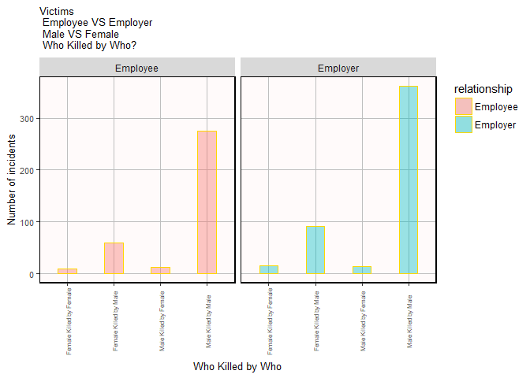

```r
ggplot(empyr.empee.sex ,aes(x = who.killed.who.sex, y=sex.freq, fill=relationship))+
  geom_bar(stat="identity", alpha=0.4,col="gold", width=0.4)+facet_wrap(~ relationship)+
  homi.theme+
  ggtitle("Victims \n Employee VS Employer \n Male VS Female \n Who Killed by Who?")+
  labs(x= "Who Killed by Who",
       y= "Number of incidents")+
  theme(axis.text.x=element_text(size= 6, angle=90,hjust = 0.5),
        axis.title.y=element_text(size=10),
        axis.title.x=element_text(size=10))+
  theme(plot.title = element_text(size = 10))
```

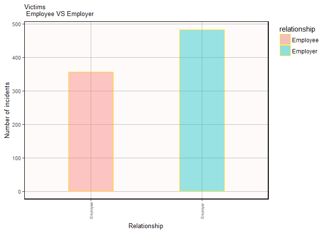

```r
ggplot(employee.employer.crime ,aes(x=relationship,fill = relationship))+
  geom_bar(alpha=0.4,col="gold", width=0.4)+
  homi.theme+
  ggtitle("Victims \n Employee VS Employer")+labs(x= "Relationship",
                                                  y= "Number of incidents")+
  theme(axis.text.x=element_text(size= 6, angle=90,hjust = 0.5),
        axis.title.y=element_text(size=10),
        axis.title.x=element_text(size=10))+
  theme(plot.title = element_text(size = 10))
```

#### Ex-Husband VS Ex-Wife / Older or Younger

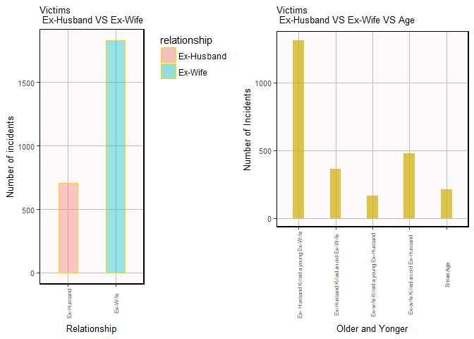

```r
ex.h.vs.ex.w <- ggplot(ex.husband.ex.wife.crime ,aes(x=relationship,fill = relationship))+
  geom_bar(alpha=0.4,col="gold", width=0.4)+
  homi.theme+
  ggtitle("Victims \n Ex-Husband VS Ex-Wife")+labs(x= "Relationship",
                                                   y= "Number of incidents")+theme(axis.text.x=element_text(size= 6, angle=90,hjust = 0.5),
        axis.title.y=element_text(size=10),
        axis.title.x=element_text(size=10))+
  theme(plot.title = element_text(size = 10))

ex.h.vs.ex.w.age <- ggplot(ex.husband.ex.wife.crime, aes(x= older.or.younger))+geom_bar(alpha=0.7,fill="gold3", width=0.3)+
  homi.theme+
  ggtitle("Victims \n Ex-Husband VS Ex-Wife VS Age")+
  labs(x="Older and Yonger",
       y="Number of Incidents")+
  theme(axis.text.x=element_text(size= 6, angle=90,hjust = 0.5),
        axis.title.y=element_text(size=10),
        axis.title.x=element_text(size=10))+
  theme(plot.title = element_text(size = 10))

grid.arrange(ex.h.vs.ex.w,
             ex.h.vs.ex.w.age,ncol=2)
```

*No Comments !*

#### The incidents happened between the Boyfriends and Girlfriends.

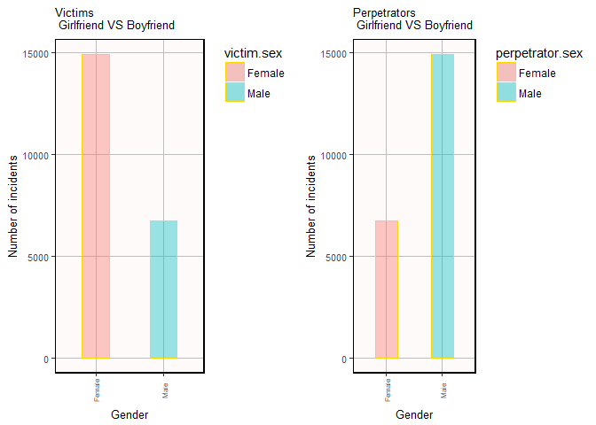

```r
plot.gf.bf.vic<-ggplot(girl.boy.crime ,aes(x=victim.sex,fill=victim.sex))+
  geom_bar(alpha=0.4,col="gold", width=0.4)+
  homi.theme+
  ggtitle("Victims \n Girlfriend VS Boyfriend")+labs(x= "Gender",
                              y= "Number of incidents")+
  theme(axis.text.x=element_text(size= 6, angle=90,hjust = 0.5),
        axis.title.y=element_text(size=10),
        axis.title.x=element_text(size=10))+
  theme(plot.title = element_text(size = 10))

plot.gf.bf.pre<-ggplot(girl.boy.crime ,aes(x=perpetrator.sex, fill=perpetrator.sex))+
  geom_bar(alpha=0.4,col="gold", width = 0.4)+
  homi.theme+
  ggtitle("Perpetrators \n Girlfriend VS Boyfriend")+labs(x= "Gender",
                                     y= "Number of incidents")+
  theme(axis.text.x=element_text(size= 6, angle=90,hjust = 0.5),
        axis.title.y=element_text(size=10),
        axis.title.x=element_text(size=10))+
  theme(plot.title = element_text(size = 10))

grid.arrange(plot.gf.bf.vic,
             plot.gf.bf.pre,
             ncol=2)
```

Regardless of the crime type, we see that the Male is much more than female as Perpetrators and Vice Versa.

#### Incidents per year and States

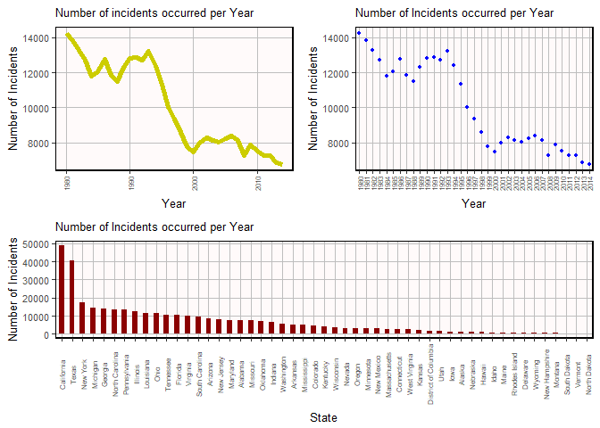

```r
plot.homic.years<-ggplot(data = by.year,
                         aes(x=as.numeric(year),
                             y=freq.year))+
    geom_line(size=2,col="yellow3")+
    homi.theme+
    ggtitle("Number of incidents occurred per Year")+
    labs(x="Year",
         y="Number of Incidents")+
    theme(axis.text.x=element_text(size= 6, angle=90,hjust = 0.5),
        axis.title.y=element_text(size=10),
        axis.title.x=element_text(size=10))+
  theme(plot.title = element_text(size = 10))

  plot.homic.years.points<-ggplot(data = by.year,
                                aes(x=as.factor(year),
                                    y=freq.year))+
    geom_point(size=1,col="blue")+
    homi.theme+
    ggtitle("Number of Incidents occurred per Year")+
    labs(x="Year",
         y="Number of Incidents")+
    theme(axis.text.x=element_text(size= 6, angle=90,hjust = 0.5),
        axis.title.y=element_text(size=10),
        axis.title.x=element_text(size=10))+
  theme(plot.title = element_text(size = 10))


  by.state$state <- fct_inorder(by.state$state)
  plot.by.state <- ggplot(data = by.state,
                          aes(x=as.factor(state),
                              y=freq.by.state))+
    geom_bar(stat= "identity", fill="darkred", width=0.5 )+
    homi.theme+
    ggtitle("Number of Incidents occurred per Year")+
    labs(x="State",
         y="Number of Incidents")+
    theme(axis.text.x=element_text(size= 6, angle=90,hjust = 0.5),
        axis.title.y=element_text(size=10),
        axis.title.x=element_text(size=10))+
  theme(plot.title = element_text(size = 10))

  grid.arrange(arrangeGrob(plot.homic.years,plot.homic.years.points,ncol=2),
               plot.by.state)
```

# closing

The next step is to see the time-line trend of each observation, to see for example the trend of Wife Killed by Husband along the time-line from 1980 to 2014..

Your comments are most welcome! and please **upvote** if you liked it.

of course I rely on your understanding, comments and your contributions.